# An introduction to neural networks with Keras

Dr. Florent Martin (Universität Regensburg)  
March 2018

**Machine Learning**

- choose a **MODEL** which depends on **PARAMETERS**
- learn from **DATA**
- choose model parameters that **FIT** the data

**Neural Networks** = family of models

**Keras** = Python Library for Neural Networks

[figure not shown]

1. Logistic Regression
   1. Iris Dataset
   2. Logistic Regression with scikit-learn
   3. Logistic Regression with Keras
2. Gradient descent
   1. Optimization
   2. Loss function
3. Neural Networks
   1. Logistic Regression again
   2. Neural Networks with hidden layers

```python
import numpy as np
import matplotlib.pyplot as plt
import pandas as pd
import seaborn as sns
```

# Part 1

# Before Neural Networks: Logistic Regression

# 1.1. Iris dataset

```python
iris  = sns.load_dataset("iris")
iris.sample(5)
```

|  | sepal_length | sepal_width | petal_length | petal_width | species |
| --- | --- | --- | --- | --- | --- |
| 114 | 5.8 | 2.8 | 5.1 | 2.4 | virginica |
| 62 | 6.0 | 2.2 | 4.0 | 1.0 | versicolor |
| 33 | 5.5 | 4.2 | 1.4 | 0.2 | setosa |
| 107 | 7.3 | 2.9 | 6.3 | 1.8 | virginica |
| 7 | 5.0 | 3.4 | 1.5 | 0.2 | setosa |

```python
iris.shape
```

```
(150, 5)
```

```python
iris.species.value_counts()
```

```
setosa        50
virginica     50
versicolor    50
Name: species, dtype: int64
```

| Setosa | **Versicolor** | **Virginica** |
| --- | --- | --- |

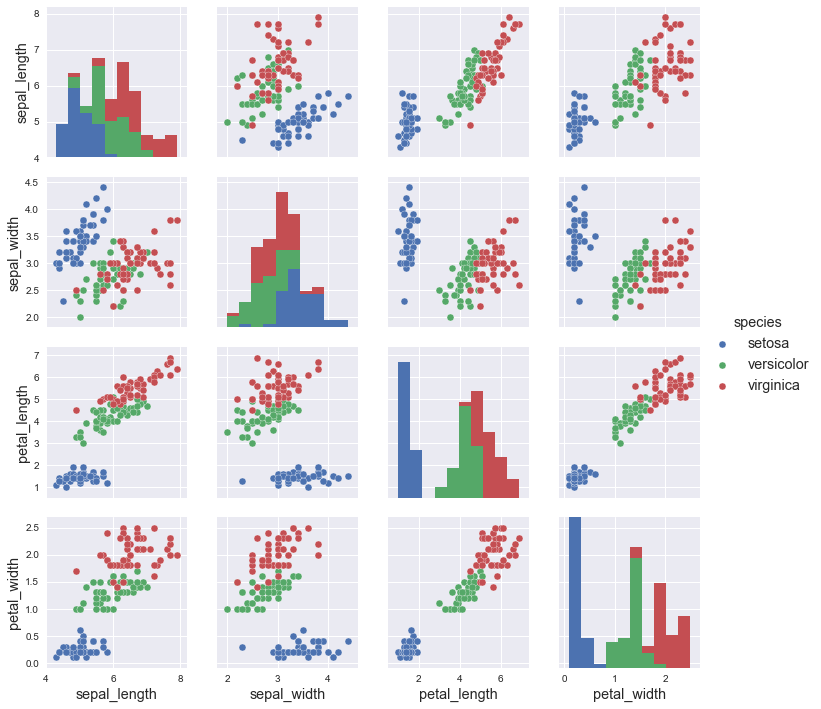

```python
sns.pairplot(iris, hue="species");
```

### Goal: knowing the petal width, predict if the iris is a virginica

**Input** = petal width

**Question**: Is the iris sample a virginica?

**Output** = False / True (equivalently 0 / 1)

```python
iris['isVirginica'] = (iris['species'] == 'virginica').astype(int)
iris.sample(5)
```

|  | sepal_length | sepal_width | petal_length | petal_width | species | isVirginica |
| --- | --- | --- | --- | --- | --- | --- |
| 92 | 5.8 | 2.6 | 4.0 | 1.2 | versicolor | 0 |
| 141 | 6.9 | 3.1 | 5.1 | 2.3 | virginica | 1 |
| 130 | 7.4 | 2.8 | 6.1 | 1.9 | virginica | 1 |
| 119 | 6.0 | 2.2 | 5.0 | 1.5 | virginica | 1 |
| 48 | 5.3 | 3.7 | 1.5 | 0.2 | setosa | 0 |

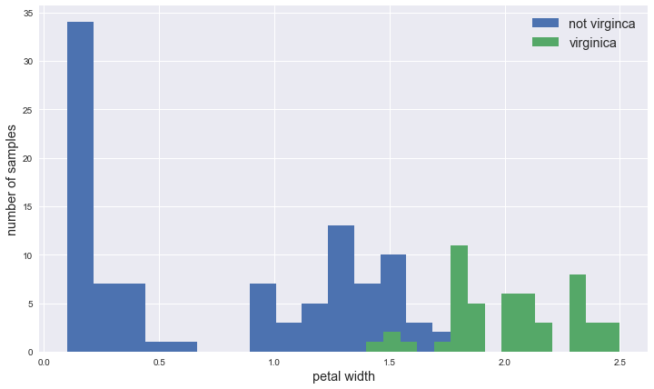

```python
fig, ax = plt.subplots( figsize=(12,7) )
iris.groupby('isVirginica').hist( column='petal_width' , ax = ax , bins=15 )
plt.legend( [ 'not virginca' , 'virginica' ] )
plt.xlabel('petal width')
plt.ylabel('number of samples')
plt.title('');
```

# Is the plant a virginica?

[figure not shown]

# Is the plant a virginica?

[figure not shown]

# Is the plant a virginica?

[figure not shown]

# Logistic Regression

**Logistic Regression** returns a function
$$ P: [0,3] \to [0,1]$$

- $x = $ petal width
- $P(x) =$ estimate of the probability that the plant is a virginica.
  $$0\leq P(x) \leq 1$$

# Sigmoid function

$$ \sigma : x \mapsto \frac{1}{1+e^{-x}}$$

```python
def sigmoid(x):
    return 1 / (1 + np.exp(-x))
```

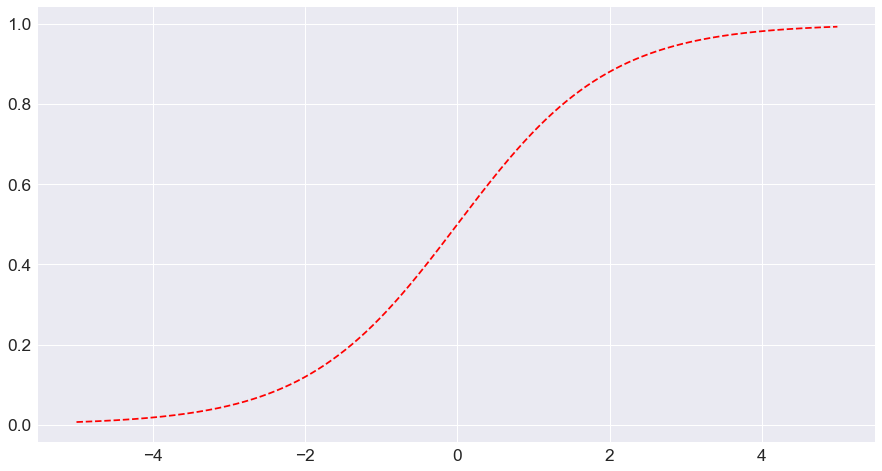

```python
x = np.arange(-5, 5, .01)
fig, ax = plt.subplots(figsize=(15,8))
plt.plot( x , sigmoid(x) , 'r--' , label='sigmoid' );
```

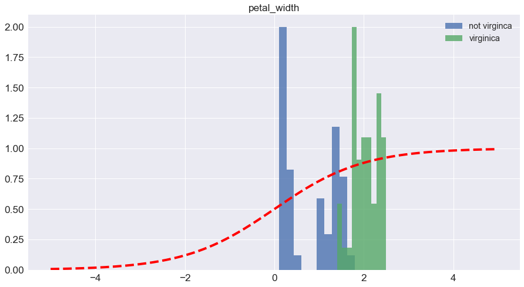

```python
fig, ax = plt.subplots(figsize=(15,8))
iris.groupby('isVirginica').hist(column='petal_width', normed=True, ax=ax , alpha=.8)
plt.legend(['not virginca', 'virginica'])
plt.plot(x, sigmoid(x),'r--', linewidth=4);
```

**Logistic Regression** is a model depending on **parameters**: **W** and **B**.
For an **input x** it ouputs the probability
$$P_{W,B}(x) = \sigma(Wx+B)$$ where $$ \sigma : x \mapsto \frac{1}{1+e^{-x}}$$ is the **sigmoid function **.

## 1.2 Logistic Regression with Scikit-learn

```python
from sklearn.linear_model import LogisticRegression
model = LogisticRegression()
```

```python
model.fit( iris[['petal_width']] , iris['isVirginica'] )
```

```
LogisticRegression(C=1.0, class_weight=None, dual=False, fit_intercept=True,
          intercept_scaling=1, max_iter=100, multi_class='ovr', n_jobs=1,
          penalty='l2', random_state=None, solver='liblinear', tol=0.0001,
          verbose=0, warm_start=False)
```

```python
w , b = model.coef_ , model.intercept_
print(w,b)
```

```
[[2.62]] [-4.22]
```

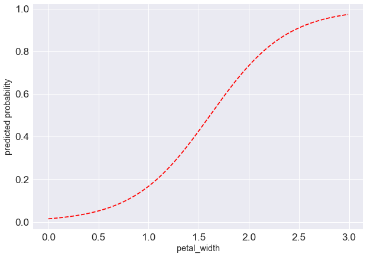

```python
petal_widths = np.arange(0,3,0.01)
predicted_proba = model.predict_proba(petal_widths.reshape(-1,1))[:,1]
plt.figure(figsize=(10,7))
plt.plot(petal_widths, predicted_proba, 'r--')
plt.xlabel('petal_width')
plt.ylabel('predicted probability');
```

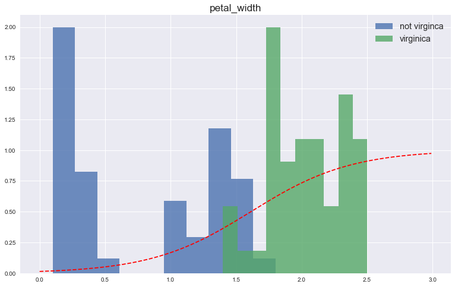

```python
fig, ax = plt.subplots(figsize=(13,8))
iris.groupby('isVirginica').hist(column='petal_width', normed=True, ax=ax, alpha=.8)
plt.legend(['not virginca', 'virginica'])
plt.plot(petal_widths, predicted_proba,'r--');
```

### How to evaluate the model?

$$ \textbf{Accuracy} = \frac{\text{number of samples correctly classified}}{\text{total number of samples}}$$

```python
model.score( iris[['petal_width']] , iris['isVirginica'] )
```

```
0.96
```

# 1.3 Logistic Regression with Keras

```python
from keras.models import Sequential
from keras.layers import Dense, Activation
```

# Graphical representation of Logistic Regression

Choose the parameters:

- W
- B

[figure not shown]

```python
model = Sequential( [
    Dense(1, input_dim=1), # for the map x -> W*x + B
    Activation('sigmoid') # for the sigmoid function
]  )
```

```python
model.compile(optimizer='sgd', loss='binary_crossentropy' , metrics=['acc'])
```

```python
model.fit( iris[['petal_width']] , iris['isVirginica'] , epochs=500 , verbose=False)
```

```python
model.get_weights()
```

```
[array([[3.03]], dtype=float32), array([-4.91], dtype=float32)]
```

```python
model.metrics_names
```

```
['loss', 'acc']
```

```python
model.evaluate( iris[['petal_width']] , iris['isVirginica'] )
```

```
[0.23716516892115275, 0.9600000015894572]
```

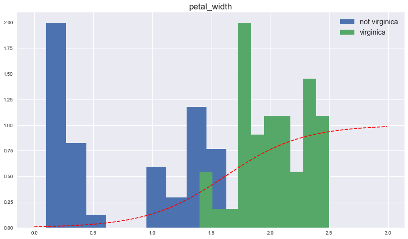

```python
fig, ax = plt.subplots(figsize=(14,8))
iris.groupby('isVirginica').hist(column='petal_width', normed=True, ax=ax)
plt.legend(['not virginica', 'virginica'])
predicted_proba = model.predict(petal_widths.reshape(-1,1))[:,0]
plt.plot(petal_widths, predicted_proba,'r--');
```

# Part 2

# Gradient descent

## How does Logistic Regression work?

# 2.1 Optimization

```python
model = Sequential([
    Dense(1 , input_dim=1 , kernel_regularizer=regularizers.l2(0.1)) ,
    Activation('sigmoid') ,
])
```

```python
model.compile( optimizer='sgd' , loss='binary_crossentropy', metrics=['accuracy'])
```

```python
model.fit( iris[['petal_width']] , iris['isVirginica'] , epochs=500)
```

```
<keras.callbacks.History at 0x1a1f6c0c18>
```

```python
x_grid, y_grid = np.mgrid[ -10:10:.1 , -10:10:.1 ]
```

```python
def get_accuracy( w , b ):
    layer =  model.layers[0]
    layer.set_weights( [ np.array([[w]]) , np.array( [b] ) ] )
    accuracy= model.evaluate( iris[['petal_width']] , iris[['isVirginica']] , verbose=0 )[1]
    return accuracy
vectorize_accuracy = np.vectorize(get_accuracy)
```

```python
acc_grid = vectorize_accuracy( x_grid , y_grid )
```

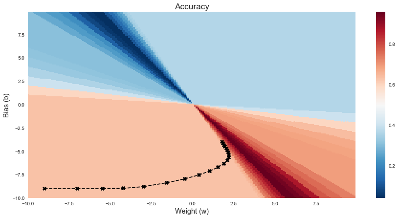

```python
fig , ax = plt.subplots(figsize=(15,7))
plt.pcolor(x_grid , y_grid , acc_grid , cmap='RdBu_r')
plt.colorbar()
ax.set(title='Accuracy', xlabel='Weight (w)', ylabel='Bias (b)');
model.layers[0].set_weights( [ np.array([[-9]]) , np.array([-9]) ] )
for i in range(20):
    old_weight, old_bias = model.get_weights()[0][0][0], model.get_weights()[1][0]
    model.fit( iris[['petal_width']] , iris['isVirginica'] , epochs=25 , verbose=0 )
    weight, bias = model.get_weights()[0][0][0] , model.get_weights()[1][0]
    plt.plot([old_weight,weight] , [old_bias,bias] , 'kX--' , markersize=8 )
```

## Problem: the accuracy is constant on huge zones

# 2.2 Loss function

$$\text{Loss} := -\frac{1}{n}\sum_{i=1}^n y_i \log(p_i) + (1-y_i)\log(1-p_i)$$

- $y_i\in \{0,1\}$ is the class of the i-th sample
- $p_i \in [0,1]$ is the predicted probability $P(x_i)$ calculated by the model

If $y=1$ $$ y \log(p) + (1-y)\log(1-p) = -\log(p)$$

If $y=0$ $$ y \log(p) + (1-y)\log(1-p) = -\log(1-p)$$

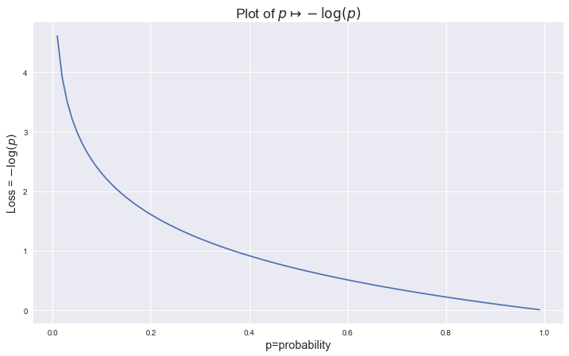

```python
probas = np.arange(0,1,.01)
loss = - np.log(probas)
plt.figure(figsize=(12,7))
plt.plot(probas , loss )
plt.xlabel('p=probability')
plt.ylabel('Loss = $-\log(p)$')
plt.title('Plot of $p \mapsto  -\log(p)$');
```

```python
model.metrics_names
```

```
['loss', 'acc']
```

```python
model.evaluate( iris[['petal_width']] , iris['isVirginica'] )
```

```
[0.547787648042043, 0.82]
```

```python
def get_loss(weight,bias):
    layer =  model.layers[0]
    layer.set_weights( [ np.array([[weight]]) , np.array([bias]) ] )
    loss = model.evaluate(iris[['petal_width']], iris[['isVirginica']], verbose=0 )[0]
    return loss
vloss = np.vectorize(get_loss)
```

```python
loss_grid = vloss(x_grid,y_grid)
```

[figure not shown]

```python
fig , ax_loss = plt.subplots(figsize=(16,7))
plt.pcolor(x_grid , y_grid , loss_grid  , cmap='RdBu_r')
plt.colorbar(); plt.contour(x_grid, y_grid, loss_grid,20)
plt.title('Loss function'); plt.xlabel('w'); plt.ylabel('b');
# model.layers[0].set_weights( [ np.array([[-9]]) , np.array([-9]) ] )
# for i in range(15):
#     old_weight, old_bias = model.get_weights()[0][0][0], model.get_weights()[1][0]
#     model.fit(iris[['petal_width']] , iris[['isVirginica']] , epochs=40 , verbose=0 )
#     weight, bias = model.get_weights()[0][0][0] , model.get_weights()[1][0]
#     plt.plot([old_weight,weight] , [old_bias,bias] , 'kX--' , markersize=8 )
```

# Gradient descent

- Goal: **minimize** the loss of the model
- At each epoch: **change** the parameters in a given **direction** to **decrease** the loss
- **direction**: calculated with **backpropagation** (differential calculus)

# Part 3

# Neural Networks

# 3.1 Logistic Regression again

# Replace the species virginica by versicolor

```python
iris['isVersicolor'] = (iris['species'] == 'versicolor').apply(int)
iris.sample(5)
```

|  | sepal_length | sepal_width | petal_length | petal_width | species | isVirginica | isVersicolor |
| --- | --- | --- | --- | --- | --- | --- | --- |
| 94 | 5.6 | 2.7 | 4.2 | 1.3 | versicolor | 0 | 1 |
| 149 | 5.9 | 3.0 | 5.1 | 1.8 | virginica | 1 | 0 |
| 15 | 5.7 | 4.4 | 1.5 | 0.4 | setosa | 0 | 0 |
| 120 | 6.9 | 3.2 | 5.7 | 2.3 | virginica | 1 | 0 |
| 96 | 5.7 | 2.9 | 4.2 | 1.3 | versicolor | 0 | 1 |

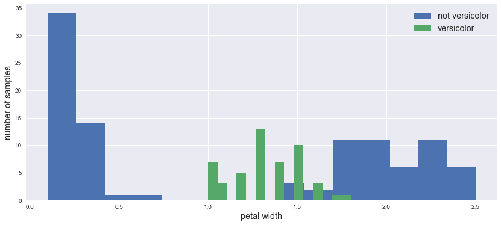

```python
fig, ax = plt.subplots(figsize=(14,6))
iris.groupby('isVersicolor').hist( column='petal_width', ax=ax , bins=15 )
plt.legend( [ 'not versicolor' , 'versicolor' ] )
plt.xlabel('petal width'); plt.ylabel('number of samples'); plt.title('');
```

## Goal: determine if an iris is a versicolor knowing its petal width

```python
model = Sequential([
    Dense( 1 , input_dim=1 ) ,
    Activation('sigmoid') ,
])
```

```python
model.compile( optimizer='sgd' , loss='binary_crossentropy' , metrics=['accuracy'] )
```

```python
model.fit( iris[['petal_width']] , iris['isVersicolor'] , epochs=500 )
```

```
<keras.callbacks.History at 0x1a22a1c978>
```

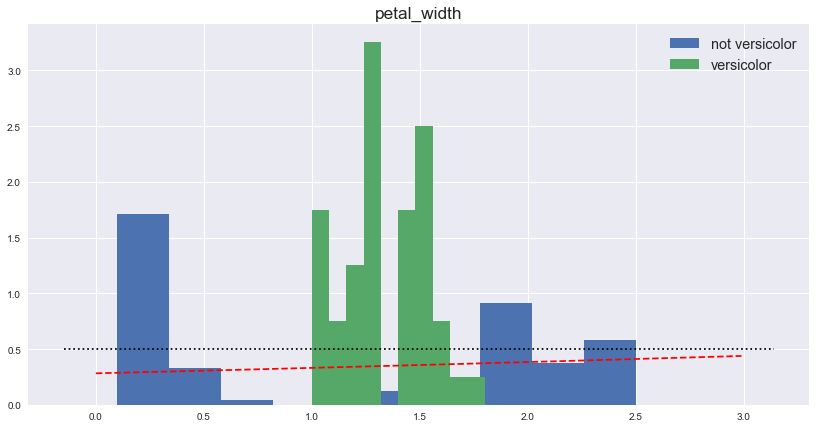

```python
fig, ax = plt.subplots(figsize=(14,7))
iris.groupby('isVersicolor').hist(column='petal_width', normed=True, ax=ax)
plt.legend(['not versicolor', 'versicolor'])
predicted_proba = model.predict(petal_widths.reshape(-1,1))[:,0]
plt.plot(petal_widths, predicted_proba,'r--',label='proba')
plt.hlines(0.5, *ax.get_xlim(), linestyles='dotted');
```

| We want | We don't want |
| --- | --- |

# BAD NEWS:

# PREDICTED PROBABILITIES BY LOGISTIC REGRESSION CAN NOT GO UP AND DOWN

# 3.2 Neural networks with hidden layers

[figure not shown]

```python
model = Sequential( [
Dense( 3, input_dim=1 ) ,
Activation('sigmoid') ,
Dense(1) ,
Activation('sigmoid')
] )
```

```python
model.compile(optimizer=optimizers.SGD(lr=.1), loss='binary_crossentropy', metrics = ['acc'])
```

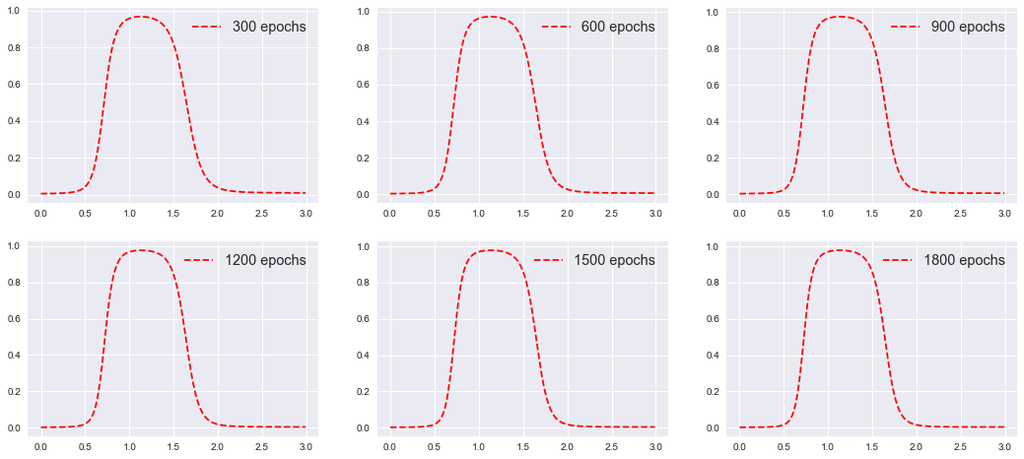

```python
plt.subplots(nrows=2  , ncols=3 , figsize=(18,8) , sharex=True , sharey=True)
for i in range(1,7):
    plt.subplot(2 , 3 , i)
    model.fit( iris[['petal_width']] , iris['isVersicolor'] , epochs=300 , verbose=0 )
    probas = model.predict(petal_widths.reshape(-1,1))[:,0]
    plt.plot( petal_widths , probas , 'r--' , label='{} epochs'.format(i*300))
    plt.ylim((0,1))
    plt.legend()
```

```python
model.evaluate( iris[['petal_width']] , iris['isVersicolor'] )
```

```
[0.11689586599667867, 0.9600000015894572]
```

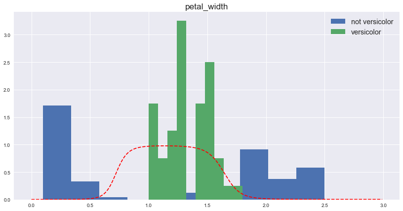

```python
fig, ax = plt.subplots(figsize=(14,7))
iris.groupby('isVersicolor').hist(column='petal_width' , normed=True , ax=ax)
plt.legend(['not versicolor', 'versicolor'])
predicted_proba = model.predict(petal_widths.reshape(-1,1))[:,0]
plt.plot(petal_widths , predicted_proba , 'r--');
```

# Conclusion

- Neural Networks are **models** depending on **parameters**
- **Logistic Regression**: the simplest neural network
- Neural Networks are made of **layers**. More layers = more expressivity
- Behind the hood: **fit** the **parameters** with the **data** to **minimize** the **loss**
- **Keras**: easy interface to use Neural Networks

# Thank you for your attention